# Stabilité d'un tri

Nous utilisons le tri à bulles pour illustrer une propriété importante des tris: la **stabilité**.

Cette propriété s'intéresse à ce qu'il se passe lorsque l'algorithme de tri rencontre **deux éléments qu'il considère comme de même valeur**.

```python
TAB = [ ("Aubert","Beatrice"),
       ("Caron","Alain"),
       ("Bonnet","Christine"),
       ("Bonnet","Anne"),
       ("Aubert","Alexandre"),
       ("Caron","Catherine"),
       ("Bonnet","Benoit"),
       ("Aubert","Denis"),
       ("Aubert","Carole"),
       ("Caron","Brigitte") ]
```

On peut envisager de trier cette liste par

- nom de famille
- prénom
- nom/prénom
- prénom/nom
- ...

Pour le rendre plus **générique** - capable de trier selon divers critères - réécrivons notre tri à bulles avec une fonction de comparaison `plus_petit` passée en paramètre

```python
def tri_a_bulles(T,plus_petit):

    N = len(T)
    for k in range(N,1,-1):
        for i in range(0,k-1):
            if plus_petit( T[i+1], T[i] ):
                T[i],T[i+1] = T[i+1],T[i]
```

Pour trier la liste par ordre alphabétique des prénoms, il suffit d'écrire une fonction de comparaison sur le deuxième élément du tuple

```python
def compare_prenoms(a,b):
    return a[1] < b[1]
```

```python
T1 = TAB.copy()
tri_a_bulles(T1,compare_prenoms)
afficher(T1)
```

```
       Nom |     Prénom
-----------+-----------
     Caron |      Alain
    Aubert |  Alexandre
    Bonnet |       Anne
    Aubert |   Beatrice
    Bonnet |     Benoit
     Caron |   Brigitte
    Aubert |     Carole
     Caron |  Catherine
    Bonnet |  Christine
    Aubert |      Denis
```

Pour trier selon l'ordre alphabétique des noms, il suffit d'utiliser la fonction de comparaison

```python
def compare_noms(a,b):
    return a[0] < b[0]
```

```python
T2 = TAB.copy()
tri_a_bulles(T2,compare_noms)
afficher(T2)
```

```
       Nom |     Prénom
-----------+-----------
    Aubert |   Beatrice
    Aubert |  Alexandre
    Aubert |      Denis
    Aubert |     Carole
    Bonnet |  Christine
    Bonnet |       Anne
    Bonnet |     Benoit
     Caron |      Alain
     Caron |  Catherine
     Caron |   Brigitte
```

Appliquons le tri par nom de famille à la liste T1, précédemment triée par prénom.

```python
T3 = T1.copy()
tri_a_bulles(T3,compare_noms)
afficher(T3)
```

```
       Nom |     Prénom
-----------+-----------
    Aubert |  Alexandre
    Aubert |   Beatrice
    Aubert |     Carole
    Aubert |      Denis
    Bonnet |       Anne
    Bonnet |     Benoit
    Bonnet |  Christine
     Caron |      Alain
     Caron |   Brigitte
     Caron |  Catherine
```

Pour chaque nom de famille, les personnes sont triées par ordre alphabétique des prénoms

**Un algorithme de tri est stable s'il ne modifie pas l'ordre initial des clés identiques**.

## Déstabiliser un tri stable

Dans l'algoritme du tri à bulle, remplaçons  
`if plus_petit( T[i+1], T[i] )` par  
`if not plus_petit( T[i], T[i+1] ):`

Cela revient à remplacer $T_{i+1} < T_i$ par $\neg( T_i < T_{i+1} )$, i.e. $T_{i+1} \leq T_{i}$.

```python
def tri_instable(T,plus_petit):

    N = len(T)
    for k in range(N,1,-1):
        for i in range(0,k-1):
            if not plus_petit( T[i], T[i+1] ):
                T[i],T[i+1] = T[i+1],T[i]
```

Ce changement modifie le traitement des éléments égaux.

- Avec `T[i] > T[i+1]`, les éléments égaux restent en place.
- Avec `T[i] >= T[i+1]`, les éléments égaux sont échangés.

Cela rend le tri instable. Trions de nouveau par nom de famille la liste T1 triée par prénom.

```python
T4 = T1.copy()
tri_instable(T4,compare_noms)
afficher(T4)
```

```
       Nom |     Prénom
-----------+-----------
    Aubert |      Denis
    Aubert |   Beatrice
    Aubert |  Alexandre
    Aubert |     Carole
    Bonnet |  Christine
    Bonnet |     Benoit
    Bonnet |       Anne
     Caron |  Catherine
     Caron |   Brigitte
     Caron |      Alain
```

Il est également possible de déstabiliser la fonction `tri_a_bulles` sans la modifier mais en lui fournissant en paramètre une mauvaise fonction de comparaison.

```python
def compare_noms_instable(a,b):
    return a[0] <= b[0]

T5 = T1.copy()
tri_a_bulles(T5,compare_noms_instable)
afficher(T5)
```

```
       Nom |     Prénom
-----------+-----------
    Aubert |      Denis
    Aubert |   Beatrice
    Aubert |  Alexandre
    Aubert |     Carole
    Bonnet |  Christine
    Bonnet |     Benoit
    Bonnet |       Anne
     Caron |  Catherine
     Caron |   Brigitte
     Caron |      Alain
```

## Stabiliser un tri instable

De même, il est toujours possible de stabiliser un algorithme de tri instable en procédant en trois étapes.

- Ajouter un indice

```python
def ajoute_indice(T):
    return [ (nom, prenom, indice) for indice, ( nom, prenom ) in enumerate(T)]

T6 = ajoute_indice(T1)
print(T6)
```

```
[('Caron', 'Alain', 0), ('Aubert', 'Alexandre', 1), ('Bonnet', 'Anne', 2), ('Aubert', 'Beatrice', 3), ('Bonnet', 'Benoit', 4), ('Caron', 'Brigitte', 5), ('Aubert', 'Carole', 6), ('Caron', 'Catherine', 7), ('Bonnet', 'Christine', 8), ('Aubert', 'Denis', 9)]
```

- Trier en utilisant l'indice pour différencier les éléments égaux par ailleurs.

```python
def compare_noms_indices(a,b):
    (nom_a, prenom_a, indice_a) = a;
    (nom_b, prenom_b, indice_b) = b;
    if(nom_a < nom_b):
        return True
    elif nom_a == nom_b:
        return indice_a < indice_b
    else:
        return False

tri_instable(T6,compare_noms_indices)

print(T6)
```

```
[('Aubert', 'Alexandre', 1), ('Aubert', 'Beatrice', 3), ('Aubert', 'Carole', 6), ('Aubert', 'Denis', 9), ('Bonnet', 'Anne', 2), ('Bonnet', 'Benoit', 4), ('Bonnet', 'Christine', 8), ('Caron', 'Alain', 0), ('Caron', 'Brigitte', 5), ('Caron', 'Catherine', 7)]
```

- Oter l'indice des éléments triés

```python
def retire_indice(T):
    return [ (nom, prenom) for (nom, prenom, indice) in T ]

T6 = retire_indice(T6)

afficher(T6)
```

```
       Nom |     Prénom
-----------+-----------
    Aubert |  Alexandre
    Aubert |   Beatrice
    Aubert |     Carole
    Aubert |      Denis
    Bonnet |       Anne
    Bonnet |     Benoit
    Bonnet |  Christine
     Caron |      Alain
     Caron |   Brigitte
     Caron |  Catherine
```

# Visualisation

Pour analyser la stabilité des tris suivants, nous utiliserons une technique plus visuelle. Elle consiste à trier une liste de 50 nombres réels aléatoires entre 0 et 7 avec trois critères de tris distincts qui comparent

- les nombres originaux
- leurs parties entières
- leurs parties fractionnaires

```python
def comp(a,b):
    return a<b

def comp_int(a,b):
    return int(a) < int(b)

def comp_frac(a,b):
    return (a-int(a)) < (b - int(b))
```

Visualisons le tri de 50 nombres aléatoires

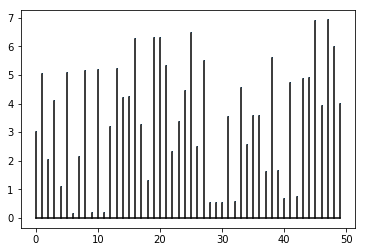

```python
import numpy as np
import matplotlib.pyplot as plt

def comp_frac(a,b):
    return (a-int(a)) < (b - int(b))

T = np.random.uniform(0,7,50)
tri_a_bulles(T,comp_frac)
plt.stem(T,markerfmt=',',linefmt='black',basefmt='black')
plt.show()
```

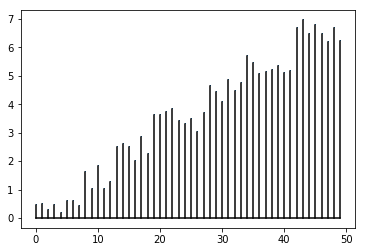

```python
def comp_int(a,b):
    return int(a) < int(b)

T = np.random.uniform(0,7,50)
tri_a_bulles(T,comp_int)
plt.stem(T,markerfmt=',',linefmt='black',basefmt='black')
plt.show()
```

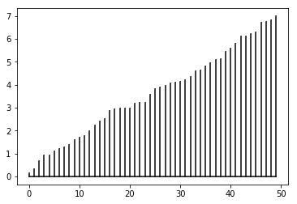

```python
T = np.random.uniform(0,7,50)
tri_a_bulles(T,comp_frac)
tri_a_bulles(T,comp_int)
plt.stem(T,markerfmt=',',linefmt='black',basefmt='black')
plt.show()
```

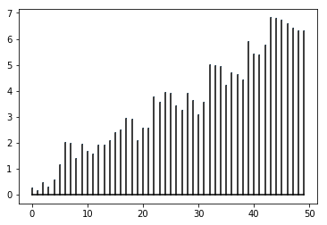

```python
T = np.random.uniform(0,7,50)
tri_instable(T,comp_frac)
tri_instable(T,comp_int)
plt.stem(T,markerfmt=',',linefmt='black',basefmt='black')
plt.show()
```

|  | [ASD1 Notebooks on GitHub.io](https://ocuisenaire.github.io/ASD1-notebooks/) © Olivier Cuisenaire, 2018 |
| --- | --- |